# QTM 151 - Quiz 2

## Try to submit as an HTML file

Print your name below

```python
# Write your answer here
print("David Chen")
```

```
David Chen
```

This quiz is open book

- You can use the lecture notes
- You will get partial credit for attempting the questions
- To get full credit, the code should run as intended
- You should NOT communicate with other students

Print the following message:

"I will abide by Emory's code of conduct"

```python
# Write your answer here:
print("I will abide by Emory's code of conduct")
```

```
I will abide by Emory's code of conduct
```

Import the libraries "numpy", "matplotlib.pyplot", and "pandas"

```python
# Write your answer here
import numpy as np
import matplotlib.pyplot as plt
import pandas as pd
```

Import the dataset "data_quiz/fifa23_players_basic.csv"

- It's a dataset on professional soccer players
- Rows correspond to players (18,539)
- Columns contain attributes of players (32)
- Try to view the dataset before starting

```python
# Write your own code
fifa23 = pd.read_csv("data_quiz/fifa23_players_basic.csv")
fifa23.head()
```

|  | Known As | Full Name | Overall | Potential | Value(in Euro) | Positions Played | Best Position | Nationality | Image Link | Age | ... | Preferred Foot | Weak Foot Rating | Skill Moves | International Reputation | National Team Name | National Team Image Link | National Team Position | National Team Jersey Number | Attacking Work Rate | Defensive Work Rate |
| --- | --- | --- | --- | --- | --- | --- | --- | --- | --- | --- | --- | --- | --- | --- | --- | --- | --- | --- | --- | --- | --- |
| 0 | L. Messi | Lionel Messi | 91 | 91 | 54000000 | RW | CAM | Argentina | https://cdn.sofifa.net/players/158/023/23_60.png | 35 | ... | Left | 4 | 4 | 5 | Argentina | https://cdn.sofifa.net/flags/ar.png | RW | 10 | Low | Low |
| 1 | K. Benzema | Karim Benzema | 91 | 91 | 64000000 | CF,ST | CF | France | https://cdn.sofifa.net/players/165/153/23_60.png | 34 | ... | Right | 4 | 4 | 4 | France | https://cdn.sofifa.net/flags/fr.png | ST | 19 | Medium | Medium |
| 2 | R. Lewandowski | Robert Lewandowski | 91 | 91 | 84000000 | ST | ST | Poland | https://cdn.sofifa.net/players/188/545/23_60.png | 33 | ... | Right | 4 | 4 | 5 | Poland | https://cdn.sofifa.net/flags/pl.png | ST | 9 | High | Medium |
| 3 | K. De Bruyne | Kevin De Bruyne | 91 | 91 | 107500000 | CM,CAM | CM | Belgium | https://cdn.sofifa.net/players/192/985/23_60.png | 31 | ... | Right | 5 | 4 | 4 | Belgium | https://cdn.sofifa.net/flags/be.png | RF | 7 | High | High |
| 4 | K. Mbappé | Kylian Mbappé | 91 | 95 | 190500000 | ST,LW | ST | France | https://cdn.sofifa.net/players/231/747/23_60.png | 23 | ... | Right | 4 | 5 | 4 | France | https://cdn.sofifa.net/flags/fr.png | ST | 10 | High | Low |

5 rows × 32 columns

(a) Create a function and apply it to a column

Step 1:

- Define a function with a parameter "year"
- If "year < 2016", status = "Joined before 2016"
- If "height >= 2016", status = "Joined on 2016 or after"
- The function returns "status"

Step 2:

- Extract the column "Joined On" in the dataset  
  (be carefeful to write the "J" and "O" capitalized)
- Create a new variable called "joined_after2016"  
  to assign each player to the correct age bracket

HINT: Use the ".apply()" function

```python
# Write your own code
def check_join_year(year):
    status = None
    if (year < 2016):
        status = "Joined before 2016"
    else:
        status = "Joined on 2016 or after"

    return status

fifa23["joined_after2016"] = fifa23["Joined On"].apply(check_join_year)
fifa23.head()
```

|  | Known As | Full Name | Overall | Potential | Value(in Euro) | Positions Played | Best Position | Nationality | Image Link | Age | ... | Weak Foot Rating | Skill Moves | International Reputation | National Team Name | National Team Image Link | National Team Position | National Team Jersey Number | Attacking Work Rate | Defensive Work Rate | joined_after2016 |
| --- | --- | --- | --- | --- | --- | --- | --- | --- | --- | --- | --- | --- | --- | --- | --- | --- | --- | --- | --- | --- | --- |
| 0 | L. Messi | Lionel Messi | 91 | 91 | 54000000 | RW | CAM | Argentina | https://cdn.sofifa.net/players/158/023/23_60.png | 35 | ... | 4 | 4 | 5 | Argentina | https://cdn.sofifa.net/flags/ar.png | RW | 10 | Low | Low | Joined on 2016 or after |
| 1 | K. Benzema | Karim Benzema | 91 | 91 | 64000000 | CF,ST | CF | France | https://cdn.sofifa.net/players/165/153/23_60.png | 34 | ... | 4 | 4 | 4 | France | https://cdn.sofifa.net/flags/fr.png | ST | 19 | Medium | Medium | Joined before 2016 |
| 2 | R. Lewandowski | Robert Lewandowski | 91 | 91 | 84000000 | ST | ST | Poland | https://cdn.sofifa.net/players/188/545/23_60.png | 33 | ... | 4 | 4 | 5 | Poland | https://cdn.sofifa.net/flags/pl.png | ST | 9 | High | Medium | Joined on 2016 or after |
| 3 | K. De Bruyne | Kevin De Bruyne | 91 | 91 | 107500000 | CM,CAM | CM | Belgium | https://cdn.sofifa.net/players/192/985/23_60.png | 31 | ... | 5 | 4 | 4 | Belgium | https://cdn.sofifa.net/flags/be.png | RF | 7 | High | High | Joined before 2016 |
| 4 | K. Mbappé | Kylian Mbappé | 91 | 95 | 190500000 | ST,LW | ST | France | https://cdn.sofifa.net/players/231/747/23_60.png | 23 | ... | 4 | 5 | 4 | France | https://cdn.sofifa.net/flags/fr.png | ST | 10 | High | Low | Joined on 2016 or after |

5 rows × 33 columns

(b) Use queries + global variables

- Compute the mean of the column "Height(in cm)"  
  and store it as a variable
- Subset the players whose value is above the mean value  
  using ".query()"

HINT: Remember that there is a special syntax for  
when the column names have spaces (see Lecture 10)  
Reference the column as `` `Height(in cm)` `` inside .query()

```python
# Write your own code
avg_height = fifa23["Height(in cm)"].mean()
above_avg_players = fifa23.query('`Height(in cm)` > @avg_height')
(above_avg_players["Height(in cm)"] <= avg_height).sum()
```

```
0
```

(c) Use sorting + ".iloc[]"

- Use ".sort_values()" to order the "Value(in Euro)" column  
  from largest to smaller
- Get a subset with the 5 players with the highest monetary valuation

```python
# Write your own code
fifa23_sorted = fifa23.sort_values(by = "Value(in Euro)", ascending = False)
fifa23_sorted.iloc[0:5, :]
```

|  | Known As | Full Name | Overall | Potential | Value(in Euro) | Positions Played | Best Position | Nationality | Image Link | Age | ... | Preferred Foot | Weak Foot Rating | Skill Moves | International Reputation | National Team Name | National Team Image Link | National Team Position | National Team Jersey Number | Attacking Work Rate | Defensive Work Rate |
| --- | --- | --- | --- | --- | --- | --- | --- | --- | --- | --- | --- | --- | --- | --- | --- | --- | --- | --- | --- | --- | --- |
| 4 | K. Mbappé | Kylian Mbappé | 91 | 95 | 190500000 | ST,LW | ST | France | https://cdn.sofifa.net/players/231/747/23_60.png | 23 | ... | Right | 4 | 5 | 4 | France | https://cdn.sofifa.net/flags/fr.png | ST | 10 | High | Low |
| 21 | E. Haaland | Erling Haaland | 88 | 94 | 148000000 | ST | ST | Norway | https://cdn.sofifa.net/players/239/085/23_60.png | 21 | ... | Left | 3 | 3 | 4 | Norway | https://cdn.sofifa.net/flags/no.png | ST | 9 | High | Medium |
| 42 | F. de Jong | Frenkie de Jong | 87 | 92 | 116500000 | CM | CM | Netherlands | https://cdn.sofifa.net/players/228/702/23_60.png | 25 | ... | Right | 3 | 4 | 3 | Netherlands | https://cdn.sofifa.net/flags/nl.png | CDM | 21 | High | Medium |
| 82 | Pedri | Pedro González López | 85 | 93 | 116000000 | CM | CM | Spain | https://cdn.sofifa.net/players/251/854/23_60.png | 19 | ... | Right | 4 | 4 | 2 | Spain | https://cdn.sofifa.net/flags/es.png | CM | 10 | High | High |
| 5 | M. Salah | Mohamed Salah | 90 | 90 | 115500000 | RW | RW | Egypt | https://cdn.sofifa.net/players/209/331/23_60.png | 30 | ... | Left | 3 | 4 | 4 | - | - | - | - | High | Medium |

5 rows × 32 columns

(d) Create a function with four inputs $f(y,x,b0,b1)$

$\qquad e2 = (y - b_0 - b_1 * x)^2$

- The function should return the sum of e2 entries
- This is the residual sum of squares (rss)
- Call the function "fn_rss"
- Let $y$ be the column "Overall" (overall score)
- Let $x$ be the column "Age"
- Does  
  $\qquad (b_0 = 50, b_1 = -6 )$ or  
  $\qquad (b_0 = 50, b_1 = 0.6 )$ or  
  $\qquad (b_0 = 50, b_1 = 6)$  
  produce the lowest value of rss?

```python
# Write your own code
def fn_rss(y, x, b0, b1):
    return ((y - b0 - b1 * x)**2).sum()

y = fifa23["Overall"]
x = fifa23["Age"]
b0 = [50] * len(fifa23)
b1_list = [[-6] * len(fifa23), [0.6] * len(fifa23), [6] * len(fifa23)]

min_rss = 2**31
min_rss_b1 = None
for b1 in b1_list:
    rss = fn_rss(y, x, b0, b1)
    print(f"b1 = {b1[0]} yields a rss of {rss}")
    if (rss < min_rss):
        min_rss = rss
        min_rss_b1 = b1[0]

print(f"b1 = {min_rss_b1} yields the smallest rss value of {min_rss}")
```

```
b1 = -6 yields a rss of 537721853
b1 = 0.6 yields a rss of 696928.52
b1 = 6 yields a rss of 353393885
b1 = 0.6 yields the smallest rss value of 696928.52
```

(e) Split a dataset into subsets

- Create `list_status = [1,2]`
- Create `list_prob = [0.5, 0.5]`
- Create a new variable $n$ with the number of rows of the dataset
- Use

  ```
  np.random.choice(list_status,
                     size = n,
                     p = list_prob)
  ```

  $\qquad$ to create a new column called "status"  
  $\qquad$ which randomly assigns each row to "1" or "2"  
  $\qquad$ with equal probability
- Use .query() to subset all observations with status == 1.  
  store it in a new dataset called "data1"
- Use .query() to subset all observations with status == 2.  
  store it in a new dataset called "data2"

```python
# Write your own code
list_status = [1,2]
list_prob = [.5, .5]
n = len(fifa23)
fifa23["status"] = np.random.choice(list_status, size = n, p = list_prob)
data1 = fifa23.query("status == 1")
data2 = fifa23.query("status == 2")
```

[output not shown]

(f) Create two overlapping histogram plots

- This function requires the two datasets you created in (e)
- Display the distribution of "Potential" for "data1" and "data2"
- Use the "alpha" option to make the graphs semitransparent
- You will need to add a legend, label the axes, and the title

Note: The goal of this question is to illustrate that random  
assignment produces very similar distributions between two groups

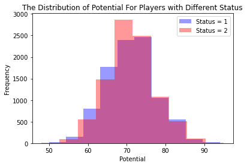

```python
# Write your own code
plt.hist(data1.Potential, alpha = 0.4, color = "blue", label = "Status = 1")
plt.hist(data2.Potential, alpha = 0.4, color = "red", label = "Status = 2")
plt.xlabel("Potential")
plt.ylabel("Frequency")
plt.title("The Distribution of Potential For Players with Different Status")
plt.legend()
```